# Python IO

Input and output of Python

## Pyhton & txt (general text file)

Basic Python function, i.e. read and write of file.

## Python & Saving an object

standard lib: JSON and Pickle

## Python & Numpy

Input and output of numpy array.

## Python & CSV

Using Pandas module.

## Python & MatLab

Using scipy's io module.

## It's more like a summary instead of a lecture. You don't need to understand everything on it, only learn it when necessary.

## Python & txt (general text file)

Create a new file and write something into it.

Basically we will discuss three function: **open, write, read.**

Ref:

[The official document for open](https://docs.python.org/3/library/functions.html#open)

[The official document for file object](https://docs.python.org/3/glossary.html#term-file-object)

Now let's see what's inside in our file.

```python
with open('./text/text.txt','r') as f:
    print(f.read())
```

```
Hello World!
1,0.235,0.645,0.457
1  0.2350000  0.6450000  0.4570000
```

Argument **'r'** means **'read mode'**, so you cannot change anything in the file.

Now open the file and write something into it.

```python
with open('./text/text.txt','w') as f:
    f.write('this is a test file.\n')
```

**'w'** means **'write mode'** and **'\n'** means change to a newline. See the change of the file.

```python
with open('./text/text.txt','r') as f:
    print(f.read())
```

```
this is a test file.
```

As you may notice, the former "Hello world" is replaced by new text. So what if I just want add something into the file?

You can use the **'append'** mode, namely change the argument from 'w' to 'a'.

```python
with open('./text/text.txt','a') as f:
    f.write("Hello World!\n")
```

```python
with open('./text/text.txt','r') as f:
    print(f.read())
```

```
this is a test file.
Hello World!
```

One may find a detailed explanation of **modes** [here](https://www.tutorialspoint.com/python/python_files_io.htm) (Doc for Python2. Python3 add a **"exclusive"** mode, you can refer the official doc for more info)

And you may notice that each time we open a file, we start with a **"with"**. If you do in this way, Python will automatically close the file. Otherwise you need to close the file manually.

Always do **not forget close** the file, it's **memory consuming**! You can do in this way:

```python
f = open('./text/text.txt','a+')
f.write("Hello World!\n")
f.close()

f = open('./text/text.txt','r')
data = f.read()
print(data)
f.close()
```

```
this is a test file.
Hello World!
Hello World!
```

You can also use "Print" function to write text.

```python
with open('./text/text.txt', 'w') as f:
    print('Hello World!', file=f)
```

```python
with open('./text/text.txt','r') as f:
    print(f.read())
```

```
Hello World!
```

String's attribute **"format"** is useful when you need customize your output:

Official ref [here](https://docs.python.org/3.6/library/string.html#format-specification-mini-language)

```python
with open('./text/text.txt','a') as f:
    f.write('1,0.235,0.645,0.457\n')
    f.write('{:d}  {:3.7f}  {:3.7f}  {:3.7f}\n'.format(1,0.235,0.645,0.457))
with open('./text/text.txt','r') as f:
    print(f.read())
```

```
Hello World!
1,0.235,0.645,0.457
1  0.2350000  0.6450000  0.4570000
```

You can see the difference between the two output.

A self-explained example is as follow:

And reference can be find: [here(Chinese version)](http://www.runoob.com/python/att-string-format.html) [here(English version)](https://docs.python.org/3.6/library/string.html#format-specification-mini-language)

```python
a = "{:.2f} {:+.2f}  {:.0f}   {:.2%} \n".format(3.14,3.14,3.14,3.14)
b = "{:+d} {:+d} {:-d} {:-d} \n".format(+1,-1,+1,-1)
c = "{4} {3} {2} {1} {0} \n".format(1,2,3,4,5)
d = "{0:0>6d} {0:0<6d} {0:3>6d} {0} \n".format(5)
e = "{:5d} {:5d} {:5d} {:5d} {:5d} \n".format(1,2,3,4,5)
f = "{:5d} {:<5d} {:5d} {:^5d} {:5d} \n".format(1,2,3,4,5)
print(a,b,c,d,e,f)
```

```
3.14 +3.14  3   314.00%
 +1 -1 1 -1
 5 4 3 2 1
 000005 500000 333335 5
     1     2     3     4     5
     1 2         3   4       5
```

Now we look at the "read" function.

There are three "read" function, namely **"read", "readline" and "readlines"**. See their output below:

```python
with open('./text/text.txt','r') as f:
    print(f.read())

with open('./text/text.txt','r') as f:
    print(f.readlines())

with open('./text/text.txt','r') as f:
    print(f.readline())

with open('./text/text.txt','r') as f:
    for line in f:
        print(line)
```

```
Hello World!
1,0.235,0.645,0.457
1  0.2350000  0.6450000  0.4570000

['Hello World!\n', '1,0.235,0.645,0.457\n', '1  0.2350000  0.6450000  0.4570000\n']
Hello World!

Hello World!

1,0.235,0.645,0.457

1  0.2350000  0.6450000  0.4570000
```

read() will return a **string form of the content**.

readlines() will return a **list of each line**.

readline() return only **one line** of the text.

The first two method will load all the text into memory at once, while the readline() will load the text one by one. If your file is very **big**(e.g. 4G or larger than your memory), **read and readlines is not recommended.**

For the big file, you may consider output in this way:

```python
with open('./text/text.txt','r') as f:
    line = f.readline()
    while line:
        print(line)
        line = f.readline()
```

```
Hello World!

1,0.235,0.645,0.457

1  0.2350000  0.6450000  0.4570000
```

We just introduce the very basic read and write part of Python. But one may notice that all the discussion above based on string type. If you have a **list** or **dict**, save it to a text file is not a good choice, because you need to reconstruct **list** or **dict** from the text.

Is there any other way of saving an object?

## Python & Saving an object

First we're going to introduce **Pickle**.

Official document [here](https://docs.python.org/3.6/library/pickle.html)

Usage of Pickle is simple:

```python
import pickle

data = ['HKUST','PHYS',6810,'Rm 4402','Lift17-18']
with open('data_pickle','wb') as f:
    pickle.dump(data,f)
```

```python
with open('./pickle/data_pickle','rb') as f:
    data = pickle.load(f)
    for i in data:
        print(i)
```

```
HKUST
PHYS
6810
Rm 4402
Lift17-18
```

And you can process multiple object like this:

```python
f = open('./pickle/somedata', 'wb')
pickle.dump([1, 2, 3, 4], f)
pickle.dump('hello', f)
pickle.dump({'Apple', 'Pear', 'Banana'}, f)
f.close()

f = open('./pickle/somedata', 'rb')
print(pickle.load(f))
print(pickle.load(f))
print(pickle.load(f))
f.close()
```

```
[1, 2, 3, 4]
hello
{'Pear', 'Banana', 'Apple'}
```

You can see it's order preserved.

Pickle can save a function.

```python
import math
with open('./pickle/function','wb') as f:
    pickle.dump(math.cos,f)
```

```python
with open('./pickle/function','rb') as f:
    Cos = pickle.load(f)
    print(Cos(0))
```

```
1.0
```

As you may notice, we add a **"b"** argument when we open the file. This indicate the data pickle save is a binary file, which is not human readable.

If a human readable file is needed, one may consider JSON.

JSON is short for "JavaScript Object Notation", which is a common data format.

JSON only support `None`,`bool`,`int`,`float` and `str` datatype, and `list`,`tuple`,`dict` which contain those data.

Let's see some example.

```python
import json

data = {
    'name' : 'ACME',
    'shares' : 100,
    'price' : 542.23
}

with open('./pickle/data.json','w') as f:
    json.dump(data, f)
```

```python
with open('./pickle/data.json', 'r') as f:
    data = json.load(f)
    for key,value in data.items():
        print(key,":",value)
```

```
name : ACME
shares : 100
price : 542.23
```

You can use that to save list or tuple.

More sophisticated techniques can be found at the [official website](https://docs.python.org/3.6/library/json.html?highlight=json#module-json)

Differences between JSON and Pickle

JSON is a text serialization format (it outputs unicode text, although most of the time it is then encoded to utf-8), while pickle is a binary serialization format.

JSON is human-readable, while pickle is not.

JSON is interoperable and widely used outside of the Python ecosystem, while pickle is Python-specific.

JSON, by default, can only represent a subset of the Python built-in types, and no custom classes; pickle can represent an extremely large number of Python types (many of them automatically, by clever usage of Python’s introspection facilities; complex cases can be tackled by implementing specific object APIs).

## Python & Numpy

NumPy module from SciPy is widely used in scientific computing, and it will also be the most important module we will learn along with the Matplotlib module.

Now let's see what can we make use of NumPy.

```python
import numpy as np
import matplotlib.pyplot as plt
%matplotlib inline
```

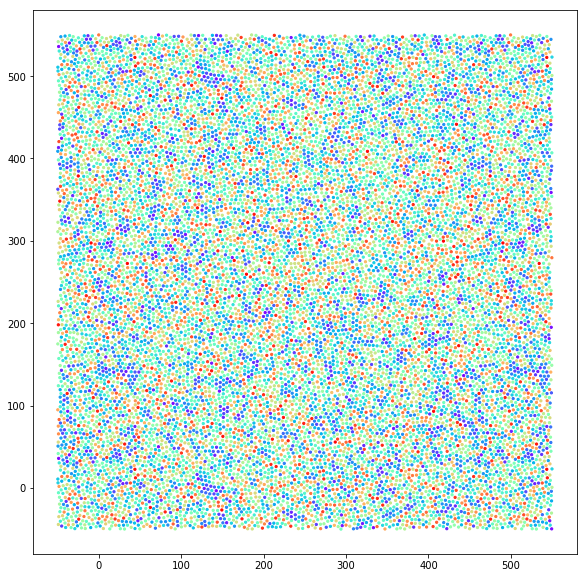

```python
data=np.load('./numpy/data.npy')
psi6 = np.load('./numpy/psi6.npy')
plt.figure(figsize=(10,10))
ax = plt.gca()
ax.set_aspect('equal')
ax.scatter(data[:,0],data[:,1],s=5,c=psi6,cmap=plt.cm.rainbow_r)
# plt.savefig('psi6.png',dpi=200)
plt.show()
```

The very basic object in NumPy is called numpy.ndarray, which is a N-dimensional matrix. NumPy has already implement common matrix operation in the ndarray(i.e. dot, transpose,etc),making it really convenient for you to use.

One may find there website [here](http://www.numpy.org/). A MatLab user may find this [tutorial](https://docs.scipy.org/doc/numpy/user/numpy-for-matlab-users.html) useful.

Let's see how to save array in NumPy.

NumPy provide a lot of useful function not only aim for its array but also for other files.

(First import numpy as np)

**np.save** **np.load**

**np.savez** **np.savez_compressed**

**np.savetxt** **np.loadtxt**

One can find more info [here](https://docs.scipy.org/doc/numpy/reference/routines.io.html)

Save a single array in to a 'npy' file.

```python
# create a new array
m = np.random.rand(100,2)
np.save('./numpy/m.npy',m)
print(m[0:5,:])
```

```
[[0.63747681 0.27082748]
 [0.73047444 0.7092957 ]
 [0.99831309 0.4086804 ]
 [0.28199021 0.31725638]
 [0.10055243 0.81826568]]
```

```python
l = np.load('./numpy/m.npy')
print(l[0:5,:])
```

```
[[0.63747681 0.27082748]
 [0.73047444 0.7092957 ]
 [0.99831309 0.4086804 ]
 [0.28199021 0.31725638]
 [0.10055243 0.81826568]]
```

Note that it's not actually open a file, the load function just return a array object. So no need to close the file.

Save multiple arrays in to a 'npz' file.

```python
np.savez('./numpy/ml.npz',x=m,y=l)
```

```python
n = np.load('./numpy/ml.npz')
print(n)
print((n['x']-n['y'])[0:5,:])
```

```
<numpy.lib.npyio.NpzFile object at 0x0000014DA3B039E8>
[[0. 0.]
 [0. 0.]
 [0. 0.]
 [0. 0.]
 [0. 0.]]
```

Also no need to close the npz file.

Function np.savez_compressed will save the file in a compressed way. It costs less disk memory and the file can also be loaded with the load function.

The loadtxt function is vert handy when dealing with text files.

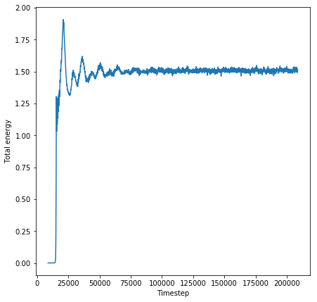

```python
data = np.loadtxt('./numpy/loadtxt_example.txt',skiprows=2,usecols=(0,4))
plt.figure(figsize=(7,7))
ax = plt.gca()
ax.plot(data[:,0],data[:,1])
ax.set_xlabel("Timestep")
ax.set_ylabel("Total energy")
plt.show()
```

One may find doc for savetxt function [here](https://docs.scipy.org/doc/numpy/reference/generated/numpy.savetxt.html).

## Python & CSV

Although Python contains a csv module in its standard library, it is relative low level and inconvenient to use. Here we're going to introduce the Pandas from Scipy.

official website [here](https://pandas.pydata.org/)

Pandas stands for **"Python Data Analysis Library"**

Reference [here](https://pandas.pydata.org/pandas-docs/stable/10min.html)

Now let's see the basic part of the module.

This is the standard way of importing pandas.

```python
import pandas as pd
```

```python
df = pd.read_csv('./csv/uk_rain_2014.csv', header=0)
```

df.head(n) give you the first n rows in dataframe.

```python
df.head(5)
```

|  | Water Year | Rain (mm) Oct-Sep | Outflow (m3/s) Oct-Sep | Rain (mm) Dec-Feb | Outflow (m3/s) Dec-Feb | Rain (mm) Jun-Aug | Outflow (m3/s) Jun-Aug |
| --- | --- | --- | --- | --- | --- | --- | --- |
| 0 | 1980/81 | 1182 | 5408 | 292 | 7248 | 174 | 2212 |
| 1 | 1981/82 | 1098 | 5112 | 257 | 7316 | 242 | 1936 |
| 2 | 1982/83 | 1156 | 5701 | 330 | 8567 | 124 | 1802 |
| 3 | 1983/84 | 993 | 4265 | 391 | 8905 | 141 | 1078 |
| 4 | 1984/85 | 1182 | 5364 | 217 | 5813 | 343 | 4313 |

df.tail(n) give you the last n rows in dataframe.

```python
df.tail(5)
```

|  | Water Year | Rain (mm) Oct-Sep | Outflow (m3/s) Oct-Sep | Rain (mm) Dec-Feb | Outflow (m3/s) Dec-Feb | Rain (mm) Jun-Aug | Outflow (m3/s) Jun-Aug |
| --- | --- | --- | --- | --- | --- | --- | --- |
| 28 | 2008/09 | 1139 | 4941 | 268 | 6690 | 323 | 3189 |
| 29 | 2009/10 | 1103 | 4738 | 255 | 6435 | 244 | 1958 |
| 30 | 2010/11 | 1053 | 4521 | 265 | 6593 | 267 | 2885 |
| 31 | 2011/12 | 1285 | 5500 | 339 | 7630 | 379 | 5261 |
| 32 | 2012/13 | 1090 | 5329 | 350 | 9615 | 187 | 1797 |

You can change the column labels by using df.columns

```python
df.columns = ['Year','rain_octsep', 'outflow_octsep',
              'rain_decfeb', 'outflow_decfeb', 'rain_junaug', 'outflow_junaug']

df.head(5)
```

|  | Year | rain_octsep | outflow_octsep | rain_decfeb | outflow_decfeb | rain_junaug | outflow_junaug |
| --- | --- | --- | --- | --- | --- | --- | --- |
| 0 | 1980/81 | 1182 | 5408 | 292 | 7248 | 174 | 2212 |
| 1 | 1981/82 | 1098 | 5112 | 257 | 7316 | 242 | 1936 |
| 2 | 1982/83 | 1156 | 5701 | 330 | 8567 | 124 | 1802 |
| 3 | 1983/84 | 993 | 4265 | 391 | 8905 | 141 | 1078 |
| 4 | 1984/85 | 1182 | 5364 | 217 | 5813 | 343 | 4313 |

You can change the format of data and get a statistic describe:

```python
pd.options.display.float_format = '{:,.3f}'.format
df.describe()
```

|  | rain_octsep | outflow_octsep | rain_decfeb | outflow_decfeb | rain_junaug | outflow_junaug |
| --- | --- | --- | --- | --- | --- | --- |
| count | 33.000 | 33.000 | 33.000 | 33.000 | 33.000 | 33.000 |
| mean | 1,129.000 | 5,019.182 | 325.364 | 7,926.545 | 237.485 | 2,439.758 |
| std | 101.900 | 658.588 | 69.995 | 1,692.800 | 66.168 | 1,025.914 |
| min | 856.000 | 3,479.000 | 206.000 | 4,578.000 | 103.000 | 1,078.000 |
| 25% | 1,053.000 | 4,506.000 | 268.000 | 6,690.000 | 193.000 | 1,797.000 |
| 50% | 1,139.000 | 5,112.000 | 309.000 | 7,630.000 | 229.000 | 2,142.000 |
| 75% | 1,182.000 | 5,497.000 | 360.000 | 8,905.000 | 280.000 | 2,959.000 |
| max | 1,387.000 | 6,391.000 | 484.000 | 11,486.000 | 379.000 | 5,261.000 |

And you can access the columns in two ways:

```python
df['rain_octsep'][0:5]
```

```
0    1182
1    1098
2    1156
3     993
4    1182
Name: rain_octsep, dtype: int64
```

```python
df.rain_octsep[28:]
```

```
28    1139
29    1103
30    1053
31    1285
32    1090
Name: rain_octsep, dtype: int64
```

Also it's easy to implement bool operation.

```python
df[df.rain_octsep < 1000]
```

|  | Year | rain_octsep | outflow_octsep | rain_decfeb | outflow_decfeb | rain_junaug | outflow_junaug |
| --- | --- | --- | --- | --- | --- | --- | --- |
| 3 | 1983/84 | 993 | 4265 | 391 | 8905 | 141 | 1078 |
| 8 | 1988/89 | 976 | 4330 | 309 | 6465 | 200 | 1440 |
| 15 | 1995/96 | 856 | 3479 | 245 | 5515 | 172 | 1439 |

```python
df[(df.rain_octsep < 1000) & (df.outflow_octsep < 4000)]
```

|  | Year | rain_octsep | outflow_octsep | rain_decfeb | outflow_decfeb | rain_junaug | outflow_junaug |
| --- | --- | --- | --- | --- | --- | --- | --- |
| 15 | 1995/96 | 856 | 3479 | 245 | 5515 | 172 | 1439 |

If we need to search string in dataframe:

```python
df[df.Year.str.startswith('199')]
```

|  | Year | rain_octsep | outflow_octsep | rain_decfeb | outflow_decfeb | rain_junaug | outflow_junaug |
| --- | --- | --- | --- | --- | --- | --- | --- |
| 10 | 1990/91 | 1022 | 4418 | 305 | 7120 | 216 | 1923 |
| 11 | 1991/92 | 1151 | 4506 | 246 | 5493 | 280 | 2118 |
| 12 | 1992/93 | 1130 | 5246 | 308 | 8751 | 219 | 2551 |
| 13 | 1993/94 | 1162 | 5583 | 422 | 10109 | 193 | 1638 |
| 14 | 1994/95 | 1110 | 5370 | 484 | 11486 | 103 | 1231 |
| 15 | 1995/96 | 856 | 3479 | 245 | 5515 | 172 | 1439 |
| 16 | 1996/97 | 1047 | 4019 | 258 | 5770 | 256 | 2102 |
| 17 | 1997/98 | 1169 | 4953 | 341 | 7747 | 285 | 3206 |
| 18 | 1998/99 | 1268 | 5824 | 360 | 8771 | 225 | 2240 |
| 19 | 1999/00 | 1204 | 5665 | 417 | 10021 | 197 | 2166 |

Use df.loc to locate specific row and column.

```python
df.loc[11,['Year','rain_octsep']]
```

```
Year           1991/92
rain_octsep       1151
Name: 11, dtype: object
```

Now I want to compare the rainfall of HK and UK.

```python
hkdf = pd.read_csv('./csv/hk_weather_data.csv',header=0)
```

```python
hkdf.head(5)
```

|  | Year | Avg Pressure(100P) | Max Temp | Avg Temp(H) | Avg Temp | Avg Temp(L) | Min Temp | Rainfall(mm) | sunshine(hr) |
| --- | --- | --- | --- | --- | --- | --- | --- | --- | --- |
| 0 | 1961 | 1,012.600 | 34.200 | 25.600 | 22.900 | 20.800 | 7.300 | 2,232.400 | 1,981.600 |
| 1 | 1962 | 1,013.200 | 35.500 | 25.800 | 22.700 | 20.400 | 6.000 | 1,741.000 | 2,395.400 |
| 2 | 1963 | 1,013.400 | 35.600 | 26.500 | 23.300 | 20.900 | 7.100 | 901.100 | 2,469.700 |
| 3 | 1964 | 1,012.700 | 33.900 | 25.700 | 22.900 | 20.500 | 7.000 | 2,432.100 | 2,029.600 |
| 4 | 1965 | 1,012.800 | 33.400 | 25.900 | 23.100 | 20.900 | 7.300 | 2,352.600 | 1,990.700 |

Combine the two dataset together and get the plot of rainfall.

First pick up the columns we need.

```python
hk_rainfall = hkdf.loc[:,['Year','Rainfall(mm)']]
hk_rainfall = hk_rainfall[(hk_rainfall.Year<=2012)&(hk_rainfall.Year>=1980)]
hk_rainfall.columns = ['Year','rainfall']
uk_rainfall = df.loc[:,['Year','rain_octsep']]
```

The 'Year' column of uk_rainfall is string type, so we need to change it to integer.

```python
def str2int(year):
    year = int(year[:4])
    return year
```

```python
print(type(uk_rainfall.Year[0]))
uk_rainfall.Year = uk_rainfall.Year.apply(str2int)
```

```
<class 'str'>
```

```python
type(uk_rainfall.Year[0])
```

```
numpy.int64
```

Now we merge two dataframe together.

```python
hk_uk_data = uk_rainfall.merge(hk_rainfall,on='Year')
```

```python
hk_uk_data.head(5)
```

|  | Year | rain_octsep | rainfall |
| --- | --- | --- | --- |
| 0 | 1980 | 1182 | 1,710.600 |
| 1 | 1981 | 1098 | 1,659.500 |
| 2 | 1982 | 1156 | 3,247.500 |
| 3 | 1983 | 993 | 2,893.800 |
| 4 | 1984 | 1182 | 2,017.000 |

And we can get a plot easily.

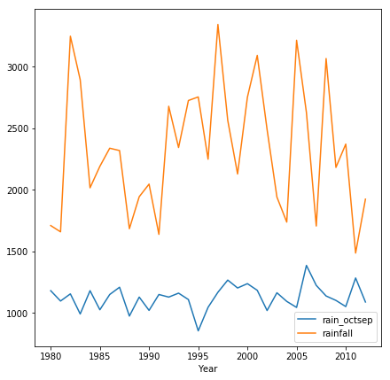

```python
hk_uk_data.plot(x='Year',y=['rain_octsep','rainfall'],figsize=(7,7))
plt.show()
```

Finally we save new dataframe to a csv file.

```python
hk_uk_data.to_csv('./csv/hk_uk_rain.csv')
```

## Python & MatLab

MatLab is a important tool for physics students.

The **io module** from scipy provide a lot of useful APIs for data reading, which include a MatLab file API. And vice versa, you can use Python API in MatLab, too.

Let's see.

One may find reference [here](https://docs.scipy.org/doc/scipy/reference/tutorial/io.html)

Mainly three function will be used:

**loadmat**: load MatLab format file.

**savemat**: save file in MatLab format.

**whosmat**: see what's inside a Mat file.

```python
import scipy.io as sio
# import numpy as np
# import matplotlib.pyplot as plt
# %matplotlib inline
```

Make sure you import all the module.

Let's see whosmat first:

```python
sio.whosmat('./mat/voro.mat')
```

```
[('vx', (2, 579), 'double'),
 ('vy', (2, 579), 'double'),
 ('x', (200, 1), 'double'),
 ('y', (200, 1), 'double')]
```

Now load the mat file.

```python
mat = sio.loadmat('./mat/voro.mat')
x = mat['x']
y = mat['y']
vx = mat['vx']
vy = mat['vy']
```

Get a figure using matplotlib.

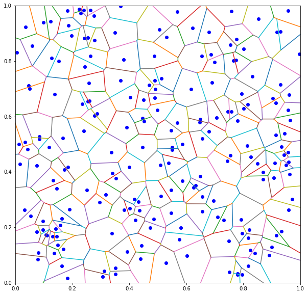

```python
plt.figure(figsize=(10,10))
plt.gca()
plt.plot(x,y,'bo',vx,vy)
plt.xlim(0,1)
plt.ylim(0,1)
plt.show()
```

Finaly we sava a random array into matlab format

```python
sio.savemat('./mat/np_rand.mat',{'position':np.random.rand(100,2)})
```

```python
sio.whosmat('./mat/np_rand.mat')
```

```
[('position', (100, 2), 'double')]
```